# **Predicting Future Traffic Volume**

**Introduction:**

This data set contains hourly information regarding traffic volume and weather conditions on a highway between Minneapolis and St. Paul, Minnesota. The data set can be obtained at: https://archive.ics.uci.edu/ml/datasets/Metro+Interstate+Traffic+Volume. The goal of this project is to apply deep learning to do time series forecasting. Specifically, given a 6-hour input window, this project will attempt to predict the traffic volume 2 hours/time steps into the future using several different recurrent neural network (RNN) architectures.

**Import libraries and read in file:**

```python
import pandas as pd
import numpy as np
import matplotlib.pyplot as plt
import seaborn as sns

import datetime
from sklearn.preprocessing import MinMaxScaler

import tensorflow as tf
from tensorflow.keras import layers, models

import warnings
warnings.filterwarnings("ignore")
```

```python
traffic = pd.read_csv('https://raw.githubusercontent.com/Jon-Lynch/CSC_578/main/Metro_Interstate_Traffic_Volume.csv')
```

## **1. Data Understanding & Preprocessing**

**Inspect Data:**

```python
# Display dataset and shape

print('Data Shape:', traffic.shape, '\n')
traffic.head()
```

```
Data Shape: (48204, 9)
```

|  | holiday | temp | rain_1h | snow_1h | clouds_all | weather_main | weather_description | date_time | traffic_volume |
| --- | --- | --- | --- | --- | --- | --- | --- | --- | --- |
| 0 | None | 288.28 | 0.0 | 0.0 | 40 | Clouds | scattered clouds | 2012-10-02 09:00:00 | 5545 |
| 1 | None | 289.36 | 0.0 | 0.0 | 75 | Clouds | broken clouds | 2012-10-02 10:00:00 | 4516 |
| 2 | None | 289.58 | 0.0 | 0.0 | 90 | Clouds | overcast clouds | 2012-10-02 11:00:00 | 4767 |
| 3 | None | 290.13 | 0.0 | 0.0 | 90 | Clouds | overcast clouds | 2012-10-02 12:00:00 | 5026 |
| 4 | None | 291.14 | 0.0 | 0.0 | 75 | Clouds | broken clouds | 2012-10-02 13:00:00 | 4918 |

**Check Data Types:**

```python
traffic.info() # Display data types
```

```
<class 'pandas.core.frame.DataFrame'>
RangeIndex: 48204 entries, 0 to 48203
Data columns (total 9 columns):
 #   Column               Non-Null Count  Dtype
---  ------               --------------  -----
 0   holiday              48204 non-null  object
 1   temp                 48204 non-null  float64
 2   rain_1h              48204 non-null  float64
 3   snow_1h              48204 non-null  float64
 4   clouds_all           48204 non-null  int64
 5   weather_main         48204 non-null  object
 6   weather_description  48204 non-null  object
 7   date_time            48204 non-null  object
 8   traffic_volume       48204 non-null  int64
dtypes: float64(3), int64(2), object(4)
memory usage: 3.3+ MB
```

There are three categorical variables (holiday, weather_main, and weather_description), one ordinal/interval variable (date_time), and five numeric variables (temp, rain_1h, snow_1h, clouds_all, and traffic_volume) including the target variable, traffic_volume. The date_time variable is in string format, and thus needs to be converted to an appropriate data type.

**Convert date_time variable to correct format:**

```python
traffic['date_time'] = pd.to_datetime(traffic['date_time'])
```

**Engineer features by separating date_time variable into Month, Day of the Week, and Hour:**

```python
traffic['month'] = traffic['date_time'].dt.month
traffic['day_of_week'] = traffic['date_time'].dt.dayofweek
traffic['hour'] = traffic['date_time'].dt.hour
```

```python
traffic.info() # Check data types again
```

```
<class 'pandas.core.frame.DataFrame'>
RangeIndex: 48204 entries, 0 to 48203
Data columns (total 12 columns):
 #   Column               Non-Null Count  Dtype
---  ------               --------------  -----
 0   holiday              48204 non-null  object
 1   temp                 48204 non-null  float64
 2   rain_1h              48204 non-null  float64
 3   snow_1h              48204 non-null  float64
 4   clouds_all           48204 non-null  int64
 5   weather_main         48204 non-null  object
 6   weather_description  48204 non-null  object
 7   date_time            48204 non-null  datetime64[ns]
 8   traffic_volume       48204 non-null  int64
 9   month                48204 non-null  int64
 10  day_of_week          48204 non-null  int64
 11  hour                 48204 non-null  int64
dtypes: datetime64[ns](1), float64(3), int64(5), object(3)
memory usage: 4.4+ MB
```

### **Exploratory Data Analysis (EDA)**

### **Categorical Variable Analysis**

```python
# Check the number of unique values in each categorical variable column

print('Categorical Variable Unique Value Counts:')
print(traffic.select_dtypes(exclude=['float64','int64', 'datetime64']).nunique(axis=0))   # Select only the categorical variables & count unique values
```

```
Categorical Variable Unique Value Counts:
holiday                12
weather_main           11
weather_description    38
dtype: int64
```

**Bar Plot of Holidays (excluding None):**

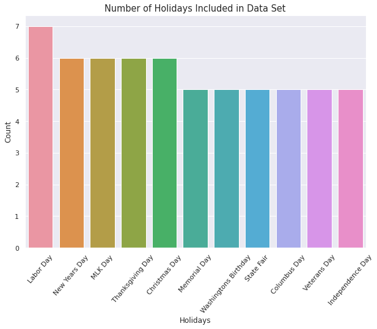

```python
holiday_abv = {'Martin Luther King Jr Day': 'MLK Day'}
traffic = traffic.replace(holiday_abv)  # convert 'Martin Luther King Jr Day' strings to 'MLK Day' for brevity

labels = list(traffic['holiday'].value_counts().index)
values = list(traffic['holiday'].value_counts())
labels = labels[1::]
values = values[1::]

plt.figure(figsize = (10,7))
sns.set(style = 'darkgrid')
sns.barplot(data=traffic, x=labels, y=values)
plt.xticks(rotation = 50)
plt.ylabel('Count')
plt.xlabel('Holidays')
plt.title('Number of Holidays Included in Data Set', fontsize = 14.5)
plt.show()
```

The variable holiday was not divided by 24 hours to obtain the value counts, indicating that holidays are only specified for 1 hour out of each 24-hour period that they encompass. Consequently, this variable may not prove very useful to the model, and should perhaps be dropped.

**Bar Plot of Short Weather Descriptions per Hour:**

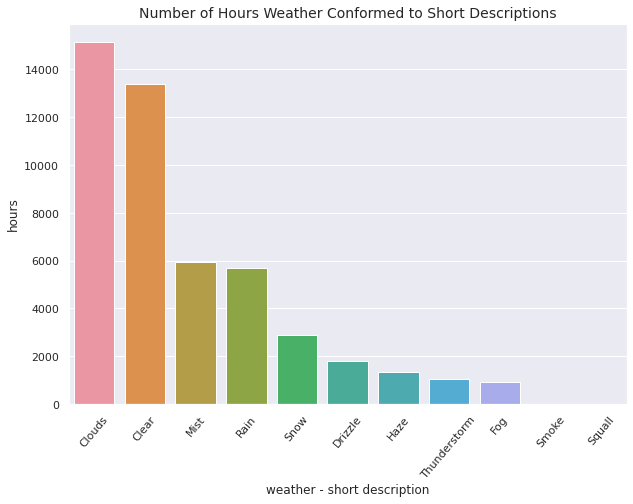

```python
labels = list(traffic['weather_main'].value_counts().index)
values = list(traffic['weather_main'].value_counts())

plt.figure(figsize = (10,7))
sns.barplot(data=traffic, x=labels, y=values)
plt.xticks(rotation = 50)
plt.ylabel('hours')
plt.xlabel('weather - short description')
plt.title('Number of Hours Weather Conformed to Short Descriptions', fontsize = 14)
plt.show()
```

This bar plot of the short weather descriptions shows the total number of hours that the weather conformed to a particular short weather description.

**Bar Plot of Long Weather Descriptions per Hour (Top 20 Categories):**

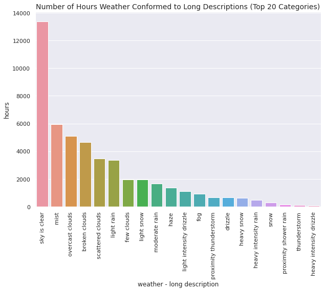

```python
weather_abv = {'Sky is Clear': 'sky is clear'}
traffic = traffic.replace(weather_abv) # convert 'Sky is Clear' strings to 'sky is clear' because these are the same

labels = list(traffic['weather_description'].value_counts().index)
values = list(traffic['weather_description'].value_counts())
labels = labels[0:20]
values = values[0:20]

plt.figure(figsize = (10,7))
sns.barplot(data=traffic, x=labels, y=values)
plt.xticks(rotation = 90)
plt.ylabel('hours')
plt.xlabel('weather - long description')
plt.title('Number of Hours Weather Conformed to Long Descriptions (Top 20 Categories)', fontsize = 14)
plt.show()
```

This bar plot of the long weather descriptions shows the total number of hours that the weather conformed to a particular long weather description. Only the top 20 categories are shown. This variable is highly related to weather_main, and perhaps only one of these two variables should be kept for modeling purposes.

### **Numeric Variable Analysis**

**Look at the Descriptive Statistics of Numeric Attributes:**

```python
traffic.describe()
```

|  | temp | rain_1h | snow_1h | clouds_all | traffic_volume | month | day_of_week | hour |
| --- | --- | --- | --- | --- | --- | --- | --- | --- |
| count | 48204.000000 | 48204.000000 | 48204.000000 | 48204.000000 | 48204.000000 | 48204.000000 | 48204.000000 | 48204.000000 |
| mean | 281.205870 | 0.334264 | 0.000222 | 49.362231 | 3259.818355 | 6.506037 | 2.984980 | 11.398162 |
| std | 13.338232 | 44.789133 | 0.008168 | 39.015750 | 1986.860670 | 3.400221 | 2.005941 | 6.940238 |
| min | 0.000000 | 0.000000 | 0.000000 | 0.000000 | 0.000000 | 1.000000 | 0.000000 | 0.000000 |
| 25% | 272.160000 | 0.000000 | 0.000000 | 1.000000 | 1193.000000 | 4.000000 | 1.000000 | 5.000000 |
| 50% | 282.450000 | 0.000000 | 0.000000 | 64.000000 | 3380.000000 | 7.000000 | 3.000000 | 11.000000 |
| 75% | 291.806000 | 0.000000 | 0.000000 | 90.000000 | 4933.000000 | 9.000000 | 5.000000 | 17.000000 |
| max | 310.070000 | 9831.300000 | 0.510000 | 100.000000 | 7280.000000 | 12.000000 | 6.000000 | 23.000000 |

The above descriptive statistics show the mean, median, and standard deviations for each numeric attribute, as well as the minimum, maximum, and first quartile (Q1/25th percentile) and third quartile (Q3/75th percentile). The numeric variable values vary signficantly in terms of range and scale, thus will need to be normalized before attempting to create any models. The last three variables (month, day_of_week, and hour) are features engineered from the original date_time variable. Also, it appears that there is at least one outlier in rain_1h (this will be further inspected).

**Plot Distributions of Numeric Variables:**

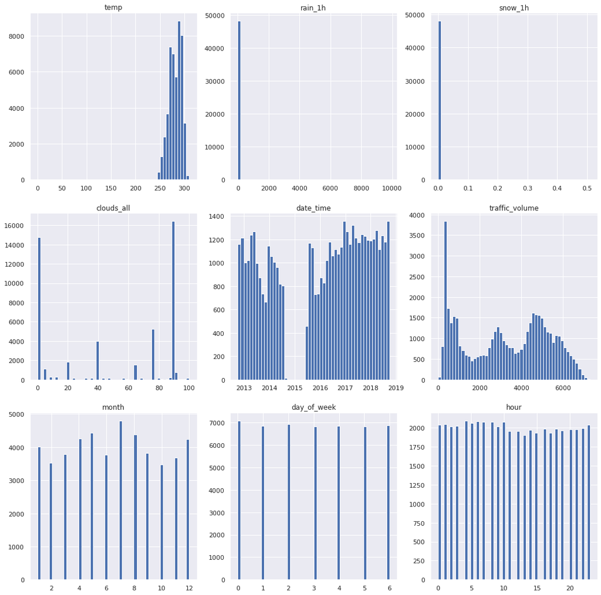

```python
# Plot Numeric Data Column Distributions

cont = list(traffic.select_dtypes(exclude=['object']).columns)   # Select numeric column names as a list

fig, ax = plt.subplots(figsize=(14, 14))
ax.axis('off')
fig.tight_layout()
for idx, i in enumerate(cont):
    fig.add_subplot(3,3,idx+1)
    plt.hist(traffic[i], bins = 52)
    plt.title(i)
```

The above histograms show the distributions of the numeric variables. One interesting thing to note is that this dataset appears to be missing a large portion of traffic volume measurements for 2015. That is, when looking at the date_time variable, it is evident that there is a large gap showing in the bins between the years 2014 and 2016, indicating a substantial reduction in traffic volume data collected/reported during this timeframe.

**Line Plot of Traffic Volume Over Time:**

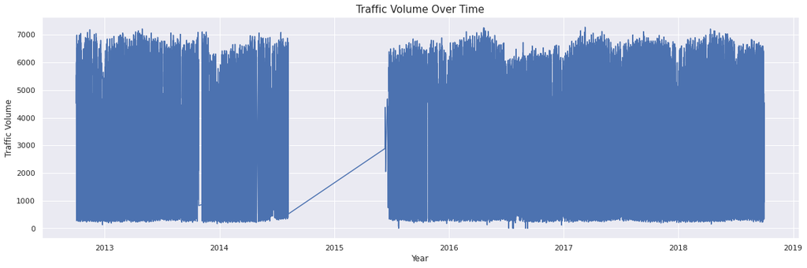

```python
plt.figure(figsize = (20,6))
sns.lineplot(data=traffic, x='date_time', y='traffic_volume')
plt.ylabel('Traffic Volume')
plt.xlabel('Year')
plt.title('Traffic Volume Over Time', fontsize = 15)
plt.show()
```

This graph is not particularly useful (beyond illustrating that there are clearly gaps in the traffic volume data collected during certain years), as there are too many observations to clearly discern trends and behavior.

**Traffic Volume by Month:**

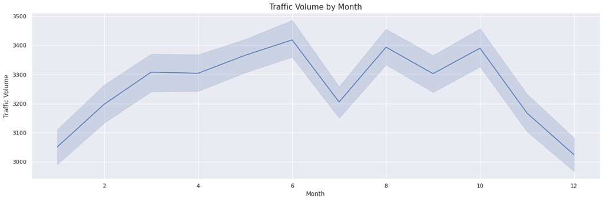

```python
plt.figure(figsize = (20,6))
sns.lineplot(data=traffic, x='month', y='traffic_volume')
plt.ylabel('Traffic Volume')
plt.xlabel('Month')
plt.title('Traffic Volume by Month', fontsize = 15)
plt.show()
```

The above line plot of the traffic volume by the month of the year illustrates the seasonality of the data set. From this graph, we can see both the slow-down of traffic volume during the winter months, as well as the increase in traffic volume during many of the summer months.

**Traffic Volume by Day of the Week:**

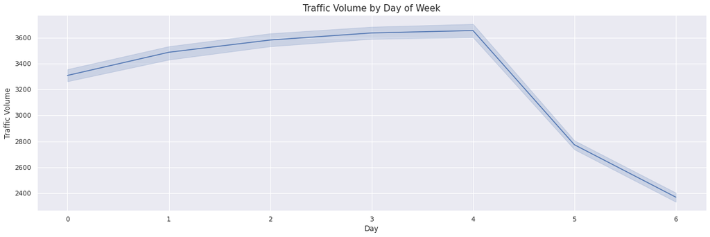

```python
plt.figure(figsize = (20,6))
sns.lineplot(data=traffic, x='day_of_week', y='traffic_volume')
plt.ylabel('Traffic Volume')
plt.xlabel('Day')
plt.title('Traffic Volume by Day of Week', fontsize = 15)
plt.show()
```

The above line plot of traffic volume by the day of the week shows that the traffic volume remains consistently high throughout the weekdays, but there is a substantial drop-off in the amount of traffic on the weekends.

**Traffic Volume by Time of Day:**

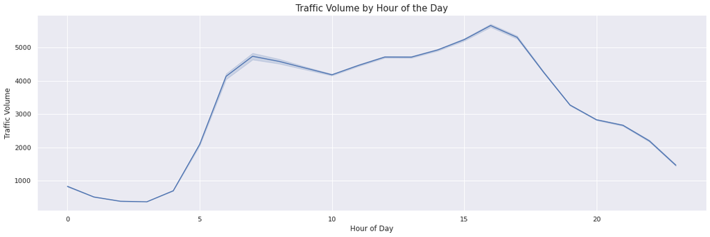

```python
plt.figure(figsize = (20,6))
sns.lineplot(data=traffic, x='hour', y='traffic_volume')
plt.ylabel('Traffic Volume')
plt.xlabel('Hour of Day')
plt.title('Traffic Volume by Hour of the Day', fontsize = 15)
plt.show()
```

The above graph shows the peak hours in traffic volume throughout the day. As one would expect, the traffic volume remains very low throughout the night, and then increases during the morning hours (presumably when people are on their way to work) and early afternoon and evening hours (when people are likely driving home).

**Drop date_time, holiday, and weather_description:**

> - date_time is adequately captured by the features engineered from this variable
> - holiday does not seem useful as it only identifies 1 hour of every 24-hour time period it actually is supposed to capture
> - weather_description too highly correlated with weather_main

```python
# drop date_time, holiday, and weather_description

traffic = traffic.drop(columns = ['date_time', 'holiday', 'weather_description'])
```

**Create Dummy Variables for weather_main:**

```python
traffic = pd.get_dummies(traffic, columns=['weather_main'])
```

**Handle Outlier:**

> - one observation (index = 24872) has an outlier in rain_1h column
> - this value will be adjusted to equal the second highest value (55.63) for rain_1h in the data set

```python
traffic[traffic['rain_1h']>50]
```

|  | temp | rain_1h | snow_1h | clouds_all | traffic_volume | month | day_of_week | hour | weather_main_Clear | weather_main_Clouds | weather_main_Drizzle | weather_main_Fog | weather_main_Haze | weather_main_Mist | weather_main_Rain | weather_main_Smoke | weather_main_Snow | weather_main_Squall | weather_main_Thunderstorm |
| --- | --- | --- | --- | --- | --- | --- | --- | --- | --- | --- | --- | --- | --- | --- | --- | --- | --- | --- | --- |
| 8247 | 289.10 | 55.63 | 0.0 | 68 | 315 | 8 | 2 | 2 | 0 | 0 | 0 | 0 | 0 | 0 | 1 | 0 | 0 | 0 | 0 |
| 24872 | 302.11 | 9831.30 | 0.0 | 75 | 5535 | 7 | 0 | 17 | 0 | 0 | 0 | 0 | 0 | 0 | 1 | 0 | 0 | 0 | 0 |

```python
traffic.loc[24872,'rain_1h'] = 55.63
```

**Split the Data into Training and Test sets:**

```python
train = traffic[0:43204]
test = traffic[43204:48204]  # last 5,000 observations for test set
```

**Normalize the Data:**

> - Here, the feature variables must be normalized separately from the target variable. This way, it will be much easier to denormalize the target predictions for the test set later on.
> - Hour variable not normalized in order to give more weight to this variable in the models, as it is the most indicative feature of traffic_volume

```python
feat_columns = ['temp', 'rain_1h', 'snow_1h','clouds_all', 'month', 'day_of_week']

feat_transformer = MinMaxScaler()
traf_transformer = MinMaxScaler()

feat_transformer = feat_transformer.fit(train[feat_columns].to_numpy())
traf_transformer = traf_transformer.fit(train[['traffic_volume']])

train.loc[:, feat_columns] = feat_transformer.transform(train[feat_columns].to_numpy())
train['traffic_volume'] = traf_transformer.transform(train[['traffic_volume']])

test.loc[:, feat_columns] = feat_transformer.transform(test[feat_columns].to_numpy())
test['traffic_volume'] = traf_transformer.transform(test[['traffic_volume']])
```

**Create X and Y Datasets:**

```python
# create X and Y from training set:
y_train = train['traffic_volume']
x_train = train.drop(['traffic_volume'], axis=1)

# create X and Y from test set:
y_test = test['traffic_volume']
x_test = test.drop(['traffic_volume'], axis =1)
```

**Create Function to Transform Datasets into Proper Format for TensorFlow Keras:**

> - function to iterate through dataset based on time steps/window (6 hours) and target step size (2 hours into the future)
> - returns arrays in format: [samples, timesteps, features] and [samples, ] for X and Y, respectively

```python
def create_dataset(X, y, time_step = 6, target_step = 2):
  Xs, ys = [], []
  for i in range(len(X) - (time_step + (target_step-1))): # iterate through range based on length of dataset and time step/target step sizes
    dist = X.iloc[i: (i + time_step)].to_numpy() # calculate windows
    Xs.append(dist)
    ys.append(y.iloc[i + time_step + (target_step-1)]) # find corresponding target (y value) for each window
  return np.array(Xs), np.array(ys)
```

**Transform Train and Test Datasets into [samples, timesteps, features] and [samples, ] formats for TensorFlow Keras:**

```python
X_train, Y_train = create_dataset(x_train, y_train, 6, 2)

X_test, Y_test = create_dataset(x_test, y_test, 6, 2)
```

## **2. Data Modeling**

### **Create Simple Baseline LSTM Model**

```python
model1 = models.Sequential([
                            layers.LSTM(128),
                            layers.Dropout(0.1),
                            layers.Dense(1)
])
```

```python
model1.compile(optimizer='adam', loss= 'mean_absolute_error')
```

```python
history1 = model1.fit(X_train, Y_train, epochs=30, validation_data=(X_test, Y_test)) # train for 30 epochs
```

**Visualize Training and Validation Loss:**

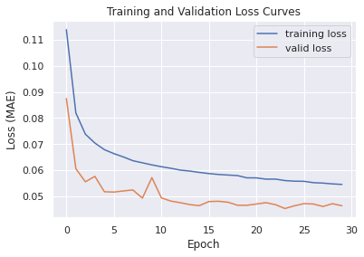

```python
plt.plot(history1.history['loss'], label='training loss')
plt.plot(history1.history['val_loss'], label = 'valid loss')
plt.xlabel('Epoch')
plt.ylabel('Loss (MAE)')
plt.legend(loc='upper right')
plt.title('Training and Validation Loss Curves')
plt.show()
```

The validation loss after training this model for 30 epochs was .0463. This will serve as a baseline model for future predictions.

**Compare Predicted Results to Actual:**

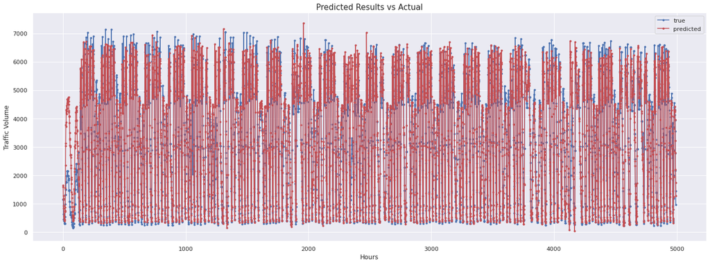

```python
predictions1 = model1.predict(X_test) # get test set predictions

test_predictions1 = traf_transformer.inverse_transform(predictions1) # denormalize predictions
y_test_inv = traf_transformer.inverse_transform(Y_test.reshape(1,-1)) # denormalize Y_test

plt.figure(figsize = (23,8))
plt.plot(y_test_inv.flatten(), marker='.', label='true')
plt.plot(test_predictions1.flatten(), color ='r', marker='.', label ='predicted')
plt.legend()
plt.ylabel('Traffic Volume')
plt.xlabel('Hours')
plt.title('Predicted Results vs Actual', fontsize = 15)
plt.show()
```

### **Create Bidirectional LSTM Model -- BEST MODEL**

```python
model2 = models.Sequential([
                            layers.Bidirectional(layers.LSTM(256, return_sequences = True)),
                            layers.Dropout(0.4),
                            layers.LSTM(128, return_sequences = True),
                            layers.Dropout(0.2),
                            layers.LSTM(64, return_sequences = True),
                            layers.Dropout(0.2),
                            layers.LSTM(32, return_sequences = False),
                            layers.Dense(1)
])
```

```python
# Learning rate/exponential decay schedule & early stopping:

lr_sched = tf.keras.optimizers.schedules.ExponentialDecay(0.001, decay_steps=100000, decay_rate=0.96, staircase=True)

early_stopping = tf.keras.callbacks.EarlyStopping(monitor='val_loss', patience=10, mode='min')
```

```python
model2.compile(loss= 'mean_absolute_error', optimizer=tf.optimizers.Adam(learning_rate=lr_sched))
```

```python
history2 = model2.fit(X_train, Y_train, validation_data=(X_test, Y_test), epochs=50, batch_size=212, callbacks=[early_stopping])
```

**Visualize Training and Validation Loss:**

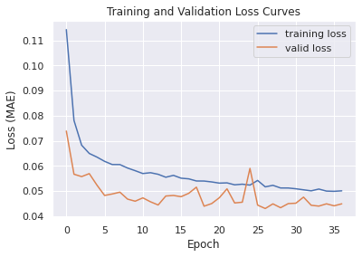

```python
plt.plot(history2.history['loss'], label='training loss')
plt.plot(history2.history['val_loss'], label = 'valid loss')
plt.xlabel('Epoch')
plt.ylabel('Loss (MAE)')
plt.legend(loc='upper right')
plt.title('Training and Validation Loss Curves')
plt.show()
```

The validation loss after training this model for 37 epochs (using early stopping) was .0449. This model is performing better than the baseline LSTM model, and is the **best model**.

**Compare Predicted Results to Actual:**

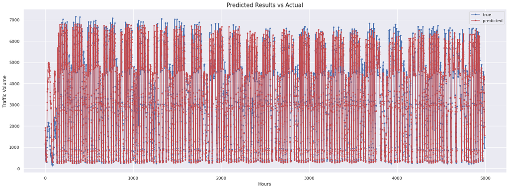

```python
predictions2 = model2.predict(X_test) # get test set predictions

test_predictions2 = traf_transformer.inverse_transform(predictions2) # denormalize predictions

plt.figure(figsize = (23,8))
plt.plot(y_test_inv.flatten(), marker='.', label='true')
plt.plot(test_predictions2.flatten(), color ='r', marker='.', label ='predicted')
plt.legend()
plt.ylabel('Traffic Volume')
plt.xlabel('Hours')
plt.title('Predicted Results vs Actual', fontsize = 15)
plt.show()
```

### **Combine CNN with RNN**

```python
model3 = models.Sequential([
                            layers.Conv1D(filters=64, kernel_size=3, strides=1, padding='same', activation='relu'),
                            layers.LSTM(64),
                            layers.Dropout(0.1),
                            layers.Dense(32, activation='relu'),
                            layers.Dense(10, activation='relu'),
                            layers.Dense(1, activation='relu')
])
```

```python
# Early stopping:

early_stopping2 = tf.keras.callbacks.EarlyStopping(monitor='val_loss', patience=9, mode='min')
```

```python
model3.compile(loss= 'mean_absolute_error', optimizer='adam')
```

```python
history3 = model3.fit(X_train, Y_train, validation_data=(X_test, Y_test), epochs=50, callbacks=[early_stopping2])
```

**Visualize Training and Validation Loss:**

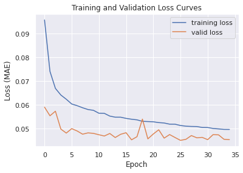

```python
plt.plot(history3.history['loss'], label='training loss')
plt.plot(history3.history['val_loss'], label = 'valid loss')
plt.xlabel('Epoch')
plt.ylabel('Loss (MAE)')
plt.legend(loc='upper right')
plt.title('Training and Validation Loss Curves')
plt.show()
```

The validation loss after training this model for 35 epochs (using early stopping) was .0454. This model's performance is better than the baseline LSTM model, but not as good as the Bidirectional LSTM model.

**Compare Predicted Results of Test Set to Actual:**

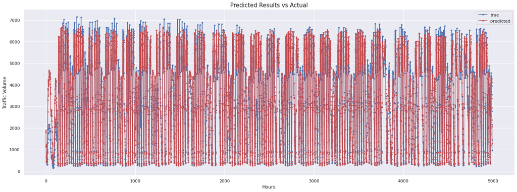

```python
predictions3 = model3.predict(X_test) # get test set predictions

test_predictions3 = traf_transformer.inverse_transform(predictions3) # denormalize predictions

plt.figure(figsize = (23,8))
plt.plot(y_test_inv.flatten(), marker='.', label='true')
plt.plot(test_predictions3.flatten(), color ='r', marker='.', label ='predicted')
plt.legend()
plt.ylabel('Traffic Volume')
plt.xlabel('Hours')
plt.title('Predicted Results vs Actual', fontsize = 15)
plt.show()
```

### **Results for Three Different Models**

| Model | Epochs | Training Loss (MAE) | Validation Loss (MAE) |
| --- | --- | --- | --- |
| Baseline LSTM | 30 | 0.0545 | 0.0463 |
| **Bidirectional LSTM** | **37** | **0.0501** | **0.0449** |
| CNN+RNN (LSTM) | 35 | 0.0497 | 0.0454 |